# Динамическая маршрутизация

Лабораторная работа №15

Гафоров Нурмухаммад

Российский университет дружбы народов, Москва, Россия

16.05.2026

# Цель работы

## Цель

Настроить динамическую маршрутизацию между территориями организации  
с использованием протокола **OSPF** в Cisco Packet Tracer.

# Ход выполнения

## Исходная топология

- Открыт готовый проект корпоративной сети
- В сети присутствуют маршрутизаторы, коммутаторы, серверы и ПК
- Настраивалась связь между Москвой и филиалом в Сочи

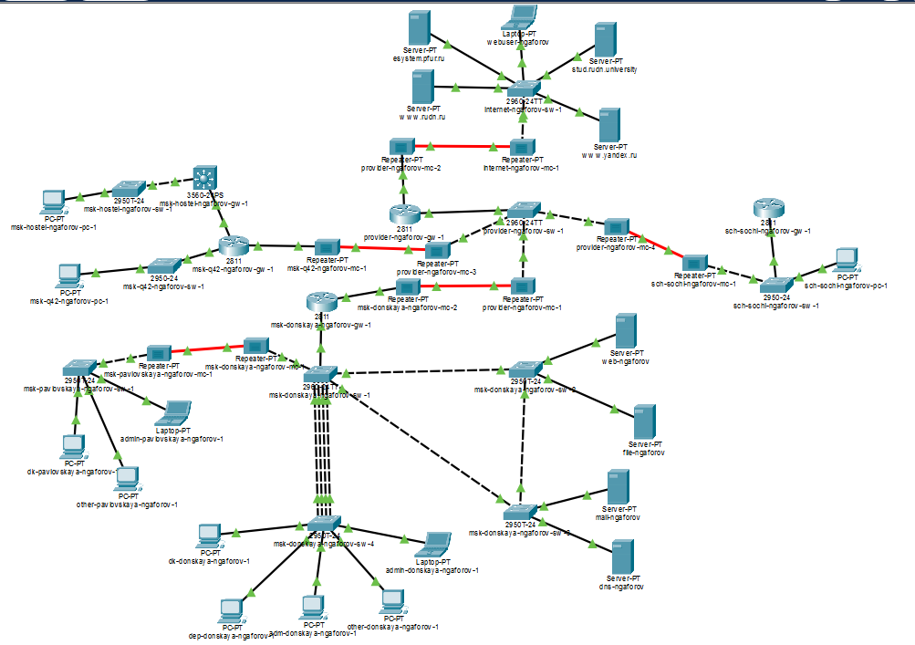

Общая топология сети

## Настройка OSPF на msk-donskaya-gw-1

- Запущен процесс **OSPF 1**
- Назначен Router ID: **10.128.254.1**
- В OSPF добавлена сеть **10.0.0.0/8**
- Использована область **area 0**

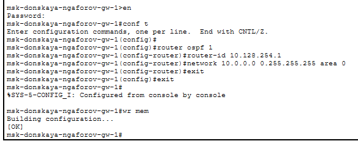

Настройка OSPF на msk-donskaya-gw-1

## Настройка msk-q42-gw-1

- Запущен процесс **OSPF 1**
- Назначен Router ID: **10.128.254.2**
- Сформировано соседство с **10.128.254.1**
- Состояние соседства перешло в **FULL**

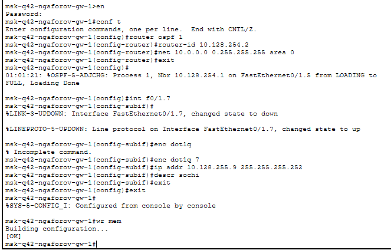

Настройка OSPF на msk-q42-gw-1

## Прямой канал q42 — sochi

- Создан подынтерфейс **FastEthernet0/1.7**
- Использована инкапсуляция **802.1Q**
- Номер VLAN: **7**
- IP-адрес: **10.128.255.9/30**
- Назначение канала: связь с Сочи

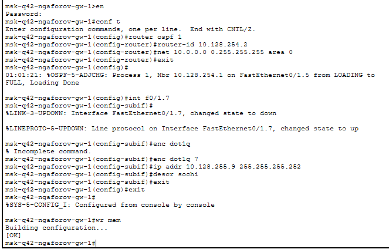

Подынтерфейс VLAN 7 на msk-q42-gw-1

## Настройка msk-hostel-gw-1

- Запущен процесс **OSPF 1**
- Назначен Router ID: **10.128.254.3**
- Добавлена сеть **10.0.0.0/8**
- Соседство с **10.128.254.2** перешло в состояние **FULL**

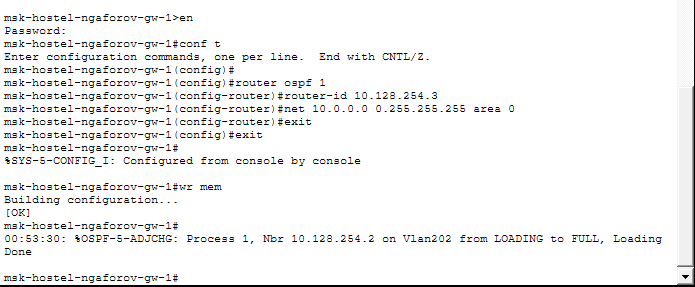

Настройка OSPF на msk-hostel-gw-1

## Настройка sch-sochi-gw-1

- Запущен процесс **OSPF 1**
- Назначен Router ID: **10.128.254.4**
- Добавлена сеть **10.0.0.0/8**
- Настроен подынтерфейс **FastEthernet0/0.7**
- IP-адрес прямого канала: **10.128.255.10/30**

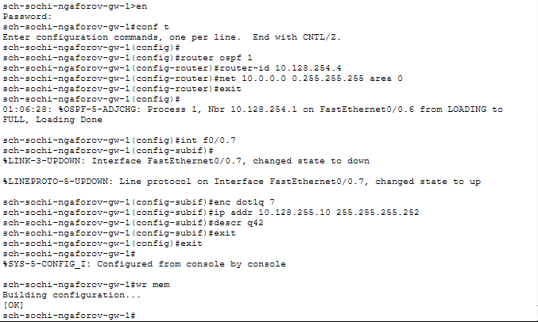

Настройка OSPF на sch-sochi-gw-1

## Настройка VLAN 7 у провайдера

- На коммутаторе **provider-ngaforov-sw-1** создан VLAN **7**
- Имя VLAN: **q42-sochi**
- Интерфейс **Vlan7** включён командой `no shutdown`
- Конфигурация сохранена

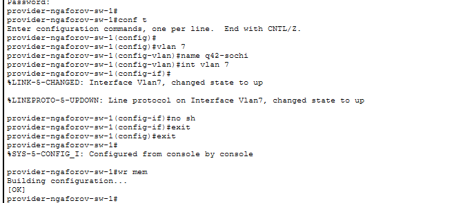

Создание VLAN 7 на provider-ngaforov-sw-1

## Настройка VLAN 7 в Сочи

- На коммутаторе **sch-sochi-ngaforov-sw-1** создан VLAN **7**
- Имя VLAN: **q42-sochi**
- Интерфейс **Vlan7** переведён в состояние **up**
- Канал q42 — sochi подготовлен к передаче трафика

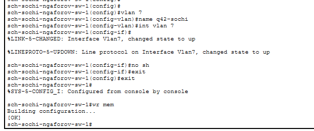

Создание VLAN 7 на sch-sochi-ngaforov-sw-1

# Проверка маршрутизации

## Проверка msk-donskaya-gw-1

- Проверены OSPF-соседи
- Найдены соседи:
  - **10.128.254.2**
  - **10.128.254.4**
- В таблице маршрутизации появились OSPF-маршруты

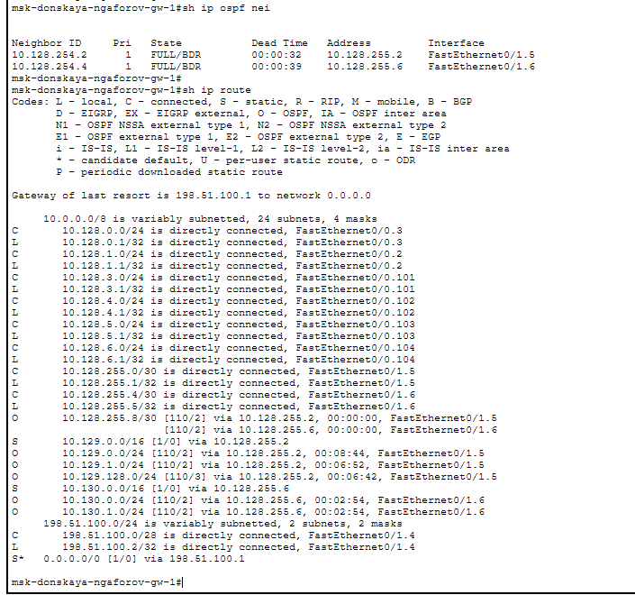

OSPF-соседи и маршруты на msk-donskaya-gw-1

## Проверка msk-q42-gw-1

- Обнаружены три OSPF-соседа:
  - **10.128.254.1**
  - **10.128.254.3**
  - **10.128.254.4**
- Соседство с Сочи работает через **FastEthernet0/1.7**
- Маршруты к сетям Сочи идут через **10.128.255.10**

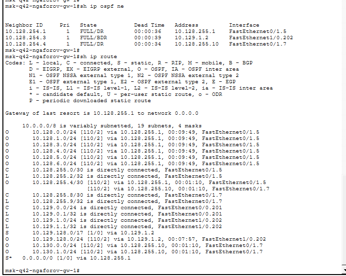

OSPF-соседи и маршруты на msk-q42-gw-1

## Проверка msk-hostel-gw-1

- Найден сосед **10.128.254.2**
- Соседство работает через **Vlan202**
- Удалённые сети доступны через OSPF
- Следующий переход: **10.129.1.1**

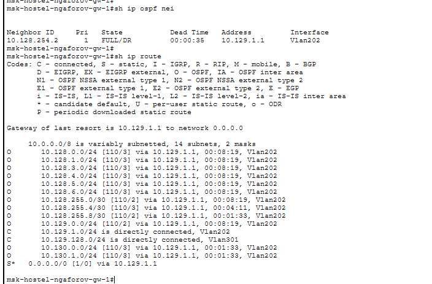

OSPF-соседи и маршруты на msk-hostel-gw-1

## Проверка sch-sochi-gw-1

- Найдены соседи:
  - **10.128.254.2**
  - **10.128.254.1**
- Прямое соединение с кварталом 42 работает через **FastEthernet0/0.7**
- Маршруты к московским сетям получены по OSPF

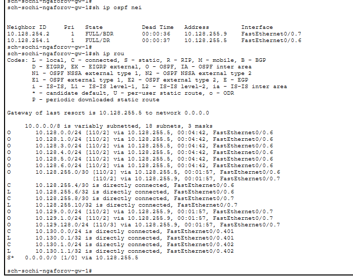

OSPF-соседи и маршруты на sch-sochi-gw-1

# Проверка ICMP

## Основной маршрут

- Проект переведён в режим **Simulation**
- Создан ICMP-пакет:
  - источник: **admin-donskaya-ngaforov-1**
  - получатель: **sch-sochi-ngaforov-pc-1**
- Пакет успешно дошёл до ПК в Сочи

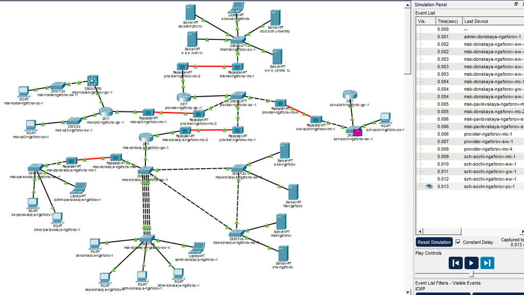

Прохождение ICMP-пакета по основному маршруту

## Отключение VLAN 6

- На коммутаторе провайдера временно отключён **VLAN 6**
- Интерфейс **Vlan6** перешёл в состояние **down**
- Основной канал до Сочи стал недоступен

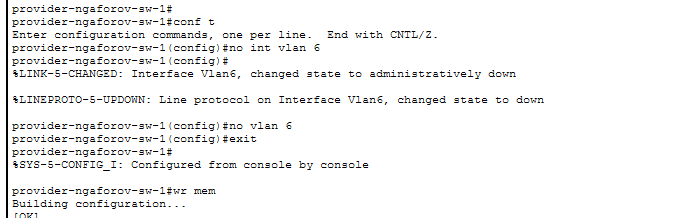

Отключение VLAN 6

## Изменение маршрута

- После отключения VLAN 6 ICMP-пакет пошёл другим путём
- Трафик был направлен через:
  - **msk-q42-ngaforov-gw-1**
  - прямой канал **q42-sochi**
  - VLAN **7**
- OSPF автоматически перестроил маршрут

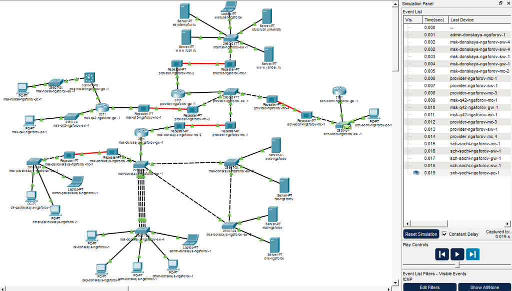

Маршрут после отключения VLAN 6

## Восстановление VLAN 6

- VLAN **6** был создан повторно
- Интерфейс **Vlan6** включён командой `no shutdown`
- Основной канал связи с Сочи восстановлен

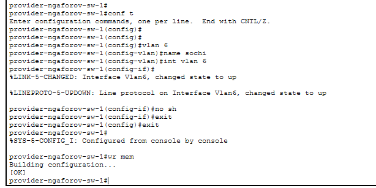

Восстановление VLAN 6

## Возврат на основной путь

- После восстановления VLAN 6 выполнена повторная симуляция
- ICMP-пакет снова пошёл по основному маршруту
- OSPF пересчитал маршрут и выбрал восстановленный канал

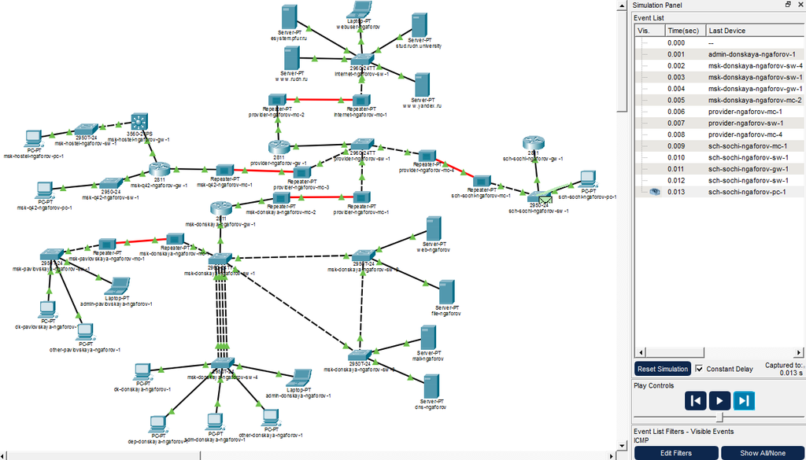

Возврат ICMP-пакета на основной маршрут

# Итог

## Вывод

- Настроена динамическая маршрутизация **OSPF**
- Создан прямой канал **q42-sochi** через VLAN **7**
- Проверены OSPF-соседства и таблицы маршрутизации
- В режиме Simulation проверено прохождение ICMP-пакетов
- При отключении VLAN **6** маршрут был перестроен автоматически
- После восстановления VLAN **6** трафик вернулся на основной путь